# EC349_Solution_Set_2New

Love Idahosa

2023-10-26

#### Instruction:

1. Create an R Markdown document
2. Follow [this link](https://www.markdownguide.org/basic-syntax/) for help with basic R syntax OR copy and past this URL in your browser: https://www.markdownguide.org/basic-syntax/
3. Follow [this link](https://markdownguide.offshoot.io/extended-syntax/#automatic-url-linking) to help with extended R syntax OR copy and past this URL in your browser: https://markdownguide.offshoot.io/extended-syntax/#automatic-url-linking
4. Answer all questions.
5. Write out each question and provide the solution immediately after using a title “**Answer**”.
   - You can copy the question directly from this document.
   - Be sure to provide an explanation of your code where relevant.
6. Upload your Markdown file to your GitHub account.
7. Provide the link to the GitHub document
8. Convert your output to a PDF document and submit on Moodle.

Complete the following:

> 1. Write your name and surname in bold font, with your Name ONLY in italics.

> 2. Print your student number and what year you are in on different lines.

> 3. Briefly state, in italics, why you are doing this Data Science Module

*I want to be able to analyse economic data in R.*

> 4. Make an unordered list of at least 3 things you have learned in this module.
- I have learned to do basic coding in R
- I have learned about version control and to create a GitHub account
- I have learned to link GitHub to RStudio

**Answer Below**

> 5. Create a table showing the 1st 5 stages of the John Rollins General Data Science Methodology and the quetions associate with them.

**Answer Below**

[output not shown]

> 6. Create an ordered list of at least 3 other Data Science methodologies.

> 7. List the weaknesses of the CRISP-DM methodology and how to address them

> 8. Download and include a University of Warwick Logo in your document.

**Answer Below**

[figure not shown]

**Answer Below**

```r
rnorm(10, mean=10, sd=2)
```

```
##  [1]  9.067063 10.551932  6.930589  6.690751 11.337612 10.384598 10.833004
##  [8] 10.425821 12.255510  9.051461
```

> 10. Write and execute a code to calculate the mean of 12 random numbers generated from the intervalof integes from 5 to 25. **Answer Below**

```r
mean(sample(5:25, 12))
```

```
## [1] 13.91667
```

> 11. Write and execute a code to create a scatter plot containing 12 points whose coordinates were randomly geenrated in the interval 5 to 25. Provide a title for the figure, label the x and y axis.

**Answer Below**

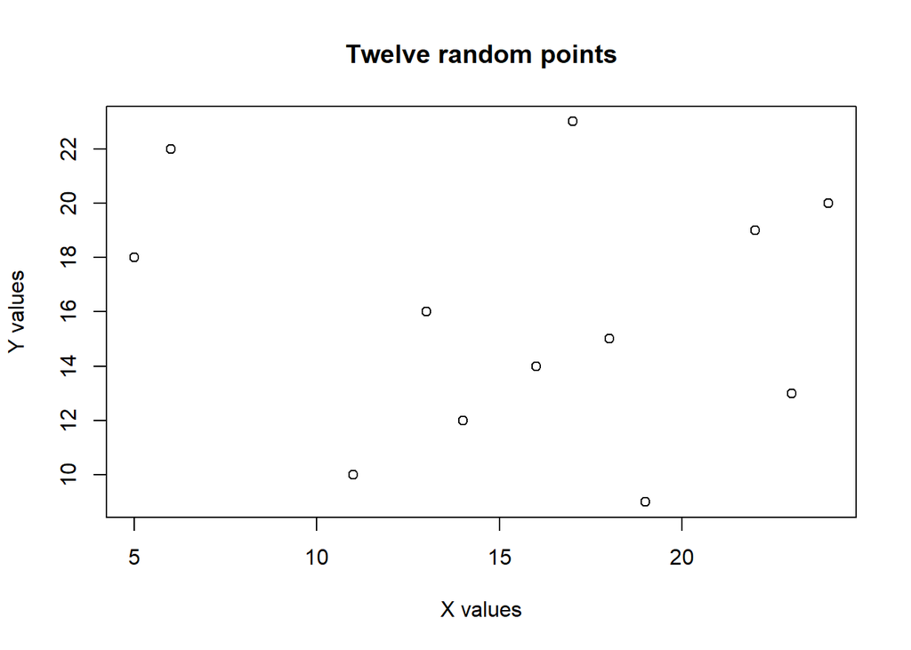

```r
plot(x=sample(5:25,12), y=sample(5:25,12), main="Twelve random points", xlab="X values", ylab="Y values")
```

> 12. Write and execute a code to create a function to calculate standard error. Then, calculate the standard error of a set of 15 randomly generated numbers from a normal distribution with mean 12 and standard deviation 3.

**Answer Below**

```r
exists("se")
```

```
## [1] FALSE
```

```r
se <- function(a) {
  x<- var(a)
  y<- length(a)
  return(sqrt(x/y))
}
testEg <- rnorm(15, mean=12, sd=3)
se(testEg)
```

```
## [1] 0.7451238
```

> 13. Given that BMI=kg/m2, where kg is the person’s weight in kilograms and m2is height in meters squared, write and execute a code to create a function that calculates the BMI of who weighs 85kg and is 1.9m tall.

**Answer Below**

```r
exists("bmi")
```

```
## [1] FALSE
```

```r
bmi<- function(weightInKg, heightInMetres) {
  return (weightInKg/heightInMetres^2)
}
bmi(85, 1.9)
```

```
## [1] 23.54571
```